# Video Games Sales Analysis And Visualization

## Platform

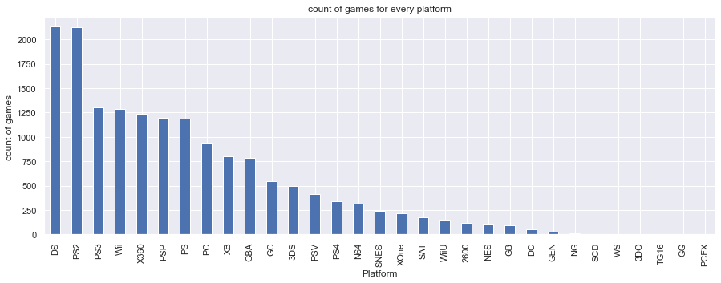

```python
high_platform.plot(kind='bar',figsize=(15,5))
plt.xlabel('Platform')
plt.ylabel('count of games ')
plt.title('count of games for every platform')
```

#### two platform (DS,PS2) have the highest number of games

## Publisher

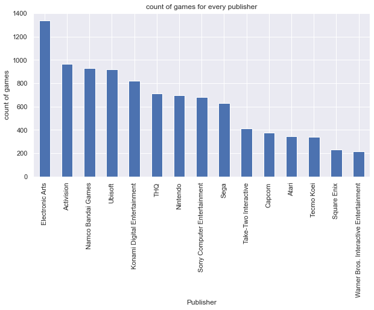

```python
df.Publisher.value_counts()[:15].plot(kind='bar',figsize=(10,5))
plt.xlabel('Publisher')
plt.ylabel('count of games')
plt.title('count of games for every publisher')
```

#### The publisher **Elctronic Arts** have highest number ofgames

## Genre

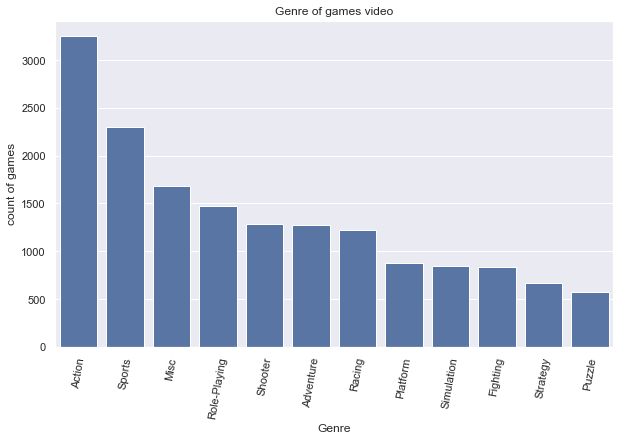

```python
fig, ax = plt.subplots( figsize = [10,6])
base_color = sb.color_palette()[0]
sb.countplot(data=df ,x='Genre',color=base_color ,order=genre_order);
plt.xticks(rotation=80);
plt.xlabel('Genre')
plt.ylabel('count of games')
plt.title('Genre of games video')
```

#### (Action) is the highest genre frequency like[Grand Theft Auto V ,Planet Monste] after that coming (sports) like[Wii Sports ,FIFA 16]

## Some observation In this part (Univariate Exploration) :

#### Most realease game , Year ,Genre , Platform

> 1. the number of games published annually is increasing significantly after the 2000s. This has the top points in the year of 2008 and 2009
> 2. (Action) is the highest genre frequency like[Grand Theft Auto V ,Planet Monste] after that coming (sports) like[Wii Sports ,FIFA 16]
> 3. The publisher *Elctronic Arts* have highest number ofgames
> 4. Top games that have been released more than once [Need for Speed: Most Wanted 12 , LEGO Marvel Super Heroes 9 , Ratatouille 9 ]
> 5. two platform (DS,PS2) have the highest number of games

## Bivariate Exploration

### the main points in this part

> 1. What are the continents with the highest contributions to the global market?
> 2. the relation between years and Genre with global sales

### First i will see the correlation between the variabeles

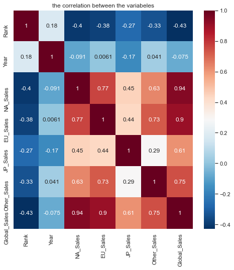

```python
plt.figure(figsize=(8,8))
sb.heatmap(df.corr(),annot=True,cmap='RdBu_r')
plt.title('the correlation between the variabeles')
```

> . Positive values shows positive correlation whereas negative values shows inverse correlation. As we can see North American sales has contributed considerably to overall Global sales;hence we can see a positive correlation between the two after that coming Europe.¶

#### see the relationship between year and Global sales

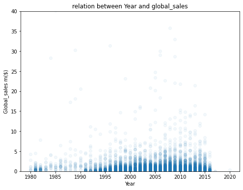

```python
plt.figure(figsize = [8, 6])
plt.scatter(data =df ,x='Year' ,y='Global_Sales' ,alpha=1/20)
plt.ylim([0,40])
plt.xlabel('Year')
plt.ylabel('Global_sales m($)')
plt.title('relation between Year and global_sales')
```

#### We can see that sales started to rise from 1995 to 2015 and the highest sales increase was in 2008 and 2009

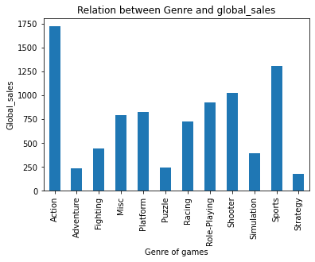

```python
df.groupby('Genre')['Global_Sales'].sum().plot(kind='bar')
plt.xlabel('Genre of games')
plt.ylabel('Global_sales')
plt.title('Relation between Genre and global_sales')
```

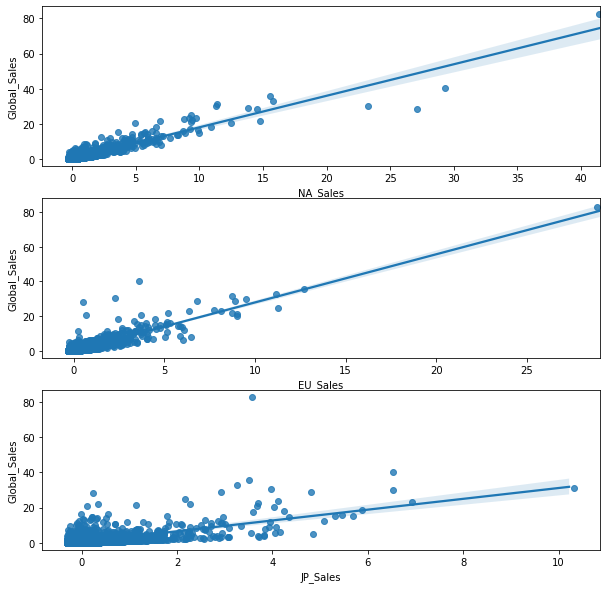

```python
fig, ax = plt.subplots(nrows=3, figsize = [10,10])

default_color = sb.color_palette()[0]
sb.regplot(data = df, x = 'NA_Sales',y='Global_Sales', color = default_color, x_jitter=0.3, ax = ax[0])
sb.regplot(data = df, x = 'EU_Sales',y='Global_Sales',  color = default_color, x_jitter=0.3, ax = ax[1])
sb.regplot(data = df, x = 'JP_Sales',y='Global_Sales',  color = default_color, x_jitter=0.3, ax = ax[2])

plt.show()
```

#### There is a strong direct relationship between sales in [the United States , Europe ] and global sales, and a direct relationship also between Japan, but not as strong as America and Europe

### Global Sales by Market¶

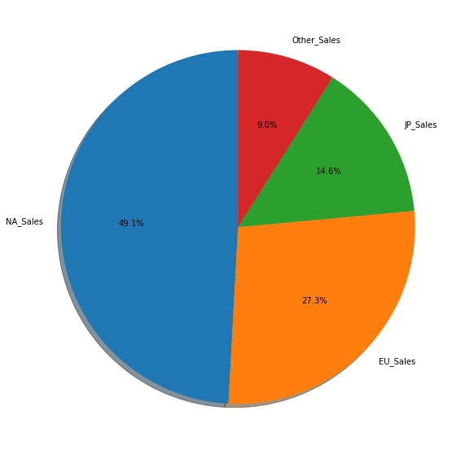

```python
country_list = ['NA_Sales', 'EU_Sales', 'JP_Sales', 'Other_Sales']
labels = country_list
plt.figure(figsize=(10,10))
sizes = df[country_list].sum()
plt.pie(sizes, labels=labels, autopct='%1.1f%%',shadow=True, startangle=90)
plt.show()
```

#### Unsurprisingly, North America makes up for nearly half of the world's video game sales. Nothing suprising here.

## Important observations in this section (Bivariate Exploration)

1. North America makes up for nearly half of the world's video game sales. Nothing suprising here
2. There is a strong direct relationship between sales in [the United States , Europe ] and global sales, and a direct relationship also between Japan, but not as strong as America and Europ
3. sales started to rise from 1995 to 2015 and the highest sales increase was in 2008 and 200
4. North American sales has contributed considerably to overall Global sales;hence we can see a positive correlation between the two after that coming Europe

## Multivariate Exploration

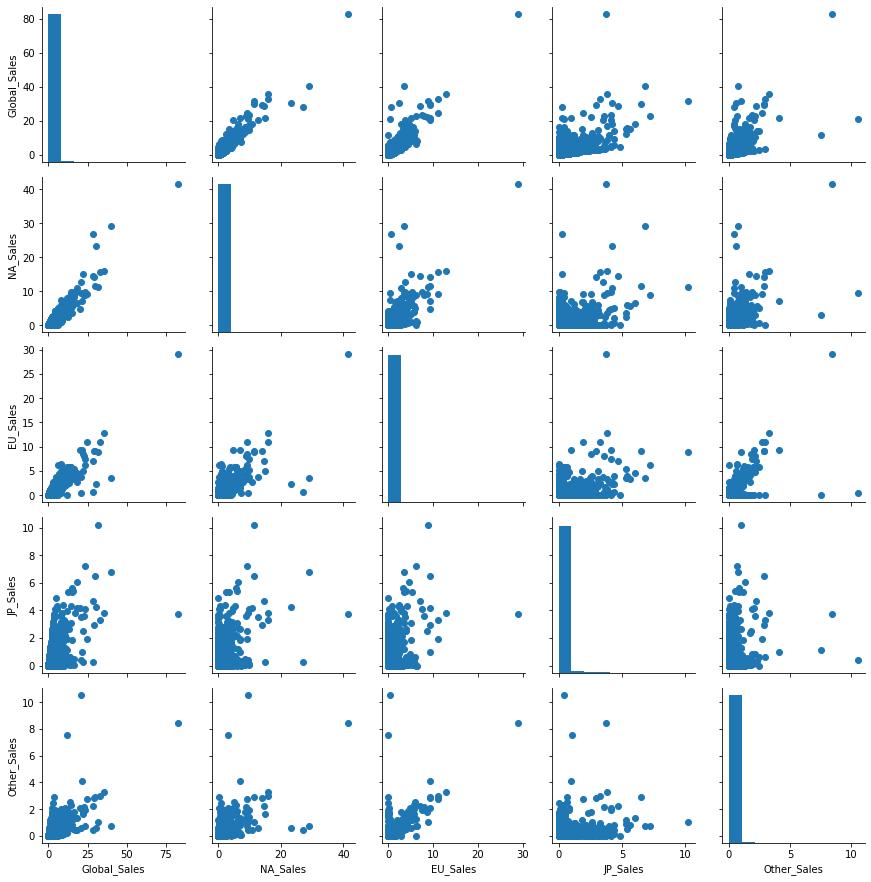

```python
g = sb.PairGrid(data = df, vars = ['Global_Sales','NA_Sales', 'EU_Sales', 'JP_Sales', 'Other_Sales'])
g.map_diag(plt.hist)
g.map_offdiag(plt.scatter)
```

### Sales compearison by genre¶

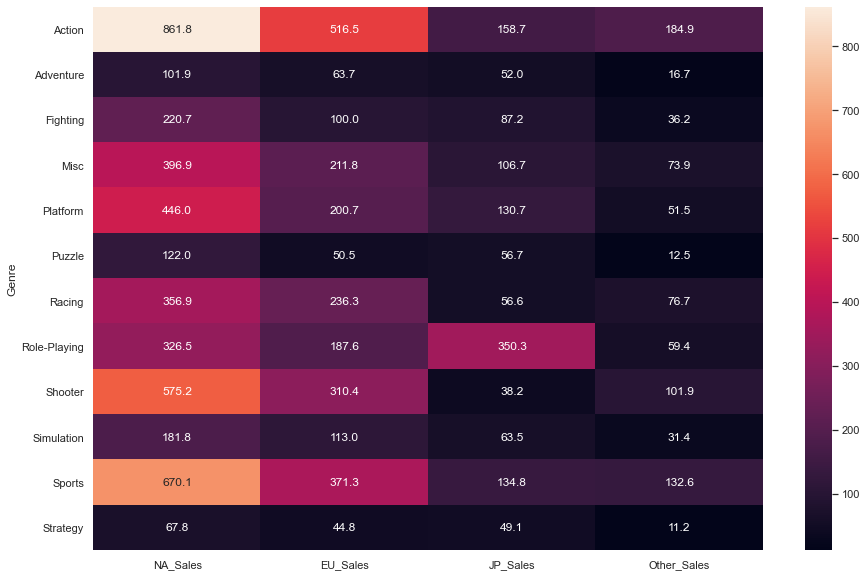

```python
plt.figure(figsize=(15, 10))
sb.set(font_scale=1)
sb.heatmap(comp_map, annot=True, fmt = '.1f')
```